# report

**Мартиросян Елизавета**

```python
!pip install stop_words
```

```python
import json
import re
import time
import warnings

import matplotlib.pyplot as plt
import nltk
import numpy as np
import pandas as pd
import seaborn as sns
from nltk.corpus import stopwords
from nltk.stem import WordNetLemmatizer
from sklearn.ensemble import AdaBoostClassifier
from sklearn.ensemble import RandomForestClassifier
from sklearn.feature_extraction.text import CountVectorizer, TfidfVectorizer
from sklearn.linear_model import RidgeClassifier
from sklearn.metrics import classification_report
from sklearn.model_selection import GridSearchCV
from sklearn.model_selection import train_test_split
from sklearn.naive_bayes import MultinomialNB
from sklearn.neighbors import KNeighborsClassifier
from sklearn.neural_network import MLPClassifier
from sklearn.pipeline import Pipeline
from sklearn.svm import SVC
from sklearn.tree import DecisionTreeClassifier
from tqdm import tqdm
```

```python
%matplotlib inline
nltk.download('stopwords')
nltk.download('punkt')
nltk.download('wordnet')
sns.set_style("whitegrid")
warnings.filterwarnings('ignore')
pd.set_option('display.max_colwidth', -1)
pd.set_option("display.max_rows", None, "display.max_columns", None)
```

# Лабораторная работа #2

### Загрузка данных

```python
articles = {}

with open('catalog.json', 'r', encoding='utf8') as data:
    articles = json.loads(data.read())['catalog']
```

### Предобработка данных

```python
texts = [article['text'] for article in articles]
categories = [article['category'] for article in articles]
```

- Заменяем на пробелы все специальных символов (то есть оставляем только буквы и цифры) r'\W'
- Заменяем на пробелы все одиночные символы (кроме цифр) r'\s+[a-zA-Z]\s+'
- Заменяем на пробелы одиночный символ из начале текста (кроме цифр)r'\^[a-zA-Z]\s+'
- Заменяем все несколько пробелов подряд на один пробел r'\s+'
- Переводим весь текст в нижний регистр
- Разбиваем на слова
- Лемматизируем с помощью WordNetLemmatizer()
- Удалять стоп слова будем при векторизации

Так же подсчитываем кол-во вхождений слов для каждой категории. (для графика)

```python
stemmer = WordNetLemmatizer()

x = []
words = {'arts': {}, 'sports': {}, 'politics': {}, 'business': {}}
stopwords_set = set(stopwords.words('english'))

for sen in tqdm(range(0, len(texts))):
    text = re.sub(r'\W', ' ', str(texts[sen]))
    text = re.sub(r'\s+[a-zA-Z]\s+', ' ', text)
    text = re.sub(r'\^[a-zA-Z]\s+', ' ', text)
    text = re.sub(r'\s+', ' ', text)
    text = text.lower()

    text = text.split()
    text = [stemmer.lemmatize(word) for word in text]

    for word in text:
        if word in stopwords_set:
            continue
        if word not in words[categories[sen]]:
            words[categories[sen]][word] = 0
        else:
            words[categories[sen]][word] += 1

    x.append(' '.join(text))
```

Слова самыми высокими частотами вхождения для каждой категории:

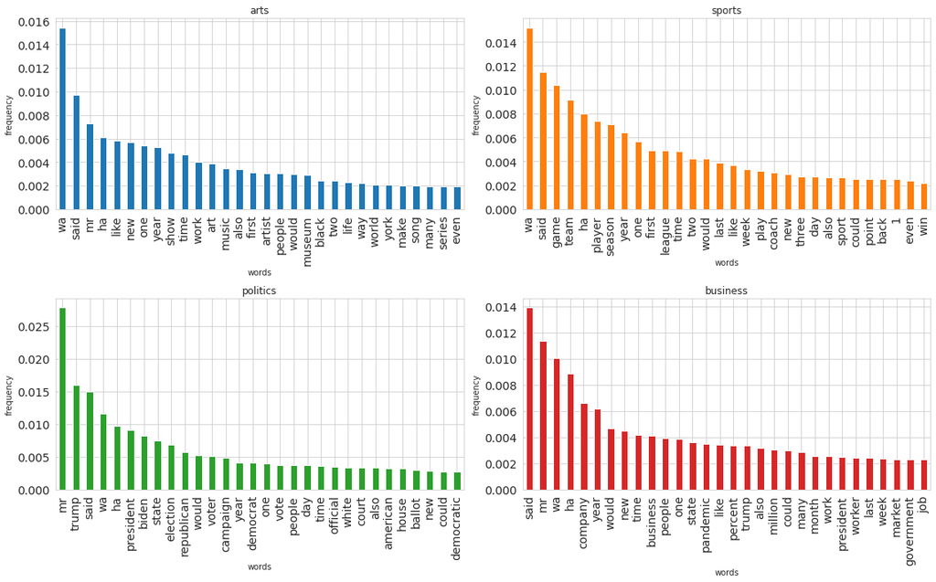

```python
fig, axes = plt.subplots(2, 2, figsize=(16, 10))
i, j = 0, 0
top = {}

for category in ['arts', 'sports', 'politics', 'business']:
    counts = pd.DataFrame(words[category].values(), index=words[category].keys())
    counts[0] /= counts[0].sum()
    counts = counts.sort_values(0, ascending=False)[:30]

    ax = counts.plot(kind='bar', fontsize=14,
                     ax = axes[i][j], color='C' + str(i * 2 + j))
    ax.set_title(category)
    ax.set_xlabel('words')
    ax.set_ylabel('frequency')
    ax.get_legend().remove()

    i = i + 1 if j == 1 else i
    j = 0 if j == 1 else j + 1

    top[category] = counts.index

fig.tight_layout()
plt.show()
```

По графикам видно, что есть некие пересечения топов:

```python
category_names = ['arts', 'sports', 'politics', 'business']
for category1 in category_names:
    for category2 in category_names:
        if category1 < category2: # чтобы не рассматривать пары дважды
            q = np.array(list(top[category1]))
            intersection = q[np.in1d(list(top[category1]), list(top[category2]))]
            print(category1, 'intersection',category2, '-', len(intersection), end=': ')
            print(*intersection)
```

```
arts intersection sports - 13: wa said ha like new one year time also first would two even
arts intersection politics - 11: wa said mr ha new one year time also people would
arts intersection business - 14: wa said mr ha like new one year time work also people would many
politics intersection sports - 11: said wa ha would year one day time also new could
business intersection sports - 13: said wa ha year would new time one like also could last week
business intersection politics - 15: said mr wa ha year would new time people one state trump also could president
```

Пересечений примерно одинаково между всеми парами категорий и их не так много на мой взгляд (особенно учитываю значения некоторых слов), по-моему, есть достаточное количество "уникальных" слов в каждой категорий, по которым можно отличать категории.

### Векторизация и Классификация

Разделяем данные на две выборки: для тренировки + отбора моделей (80%) и для тестирования (20%):

```python
x_train, x_test, y_train, y_test = train_test_split(x, categories, test_size=0.2)
```

Были выбраны следующие классификаторы: KNeighborsClassifier, SVC, RidgeClassifier, RandomForestClassifier, DecisionTreeClassifier, MultinomialNB, MLPClassifier, AdaBoostClassifier.

Векторизация: CountVectorizer, CountVectorizer + TfidfTransformer = TfidfVectorizer.

Отбирать параметры для классификаторов и векторайзеров будем с помощью GridSearchCV (использую тренировочную выборку):

```python
classifiers = [KNeighborsClassifier(), SVC(), RidgeClassifier(),
               RandomForestClassifier(), DecisionTreeClassifier(),
               MultinomialNB(), MLPClassifier(), AdaBoostClassifier()]

vectorizers = [TfidfVectorizer(stop_words = stopwords.words('english')),
               CountVectorizer(stop_words = stopwords.words('english'))]

param_grid_vectorizer = {
  'vectorizer__max_features': [1000, 1500],
  'vectorizer__max_df': [0.7, 1]
}

param_grids = [
    [{'classifier__n_neighbors': [3, 5, 8], **param_grid_vectorizer}], # KNeighborsClassifier
    [{'classifier__kernel': ['sigmoid', 'linear'],
      'classifier__C': [0.1, 1, 10], **param_grid_vectorizer}], # SVC
    [{'classifier__alpha': [0.01, 0.1, 1], **param_grid_vectorizer}], # RidgeClassifier
    [{'classifier__n_estimators': [200, 500], 'classifier__max_depth' : [4, 6, 10],
      **param_grid_vectorizer}], # RandomForestClassifier
    [{'classifier__criterion': ['gini', 'entropy'], 'classifier__max_depth': [4, 6, 10],
      **param_grid_vectorizer}], # DecisionTreeClassifier
    [{'classifier__alpha': [1, 0.1, 0.01], **param_grid_vectorizer}], # MultinomialNB
    [{'classifier__alpha': [0.01, 0.0001, 0.1], 'classifier__activation': ['logistic', 'relu'],
      **param_grid_vectorizer}], # MLPClassifier
    [{'classifier__n_estimators': [25, 100, 50], **param_grid_vectorizer}], # AdaBoostClassifier
]

pipelines = []

for classifier, param_grid in zip(classifiers, param_grids):
    for vectorizer in vectorizers:
        pipeline = Pipeline(steps=[('vectorizer', vectorizer), ('classifier', classifier)])
        pipelines.append([pipeline, param_grid])

results = []

for pipeline, param_grid in tqdm(pipelines):
    start = time.time()
    search = GridSearchCV(pipeline, param_grid)
    search.fit(x_train, y_train)
    stop = time.time()
    result = {}
    result['search_time'] = stop - start
    result['best_params_'] = search.best_params_
    result['best_score_'] = search.best_score_
    result['best_estimator_'] = search.best_estimator_
    result['cv_results_'] = search.cv_results_
    results.append(result)
```

### Сравнение

Результаты (топ 10):

```python
results_df = pd.concat([pd.DataFrame(result['cv_results_']) for result in results])

estimators = [result['best_estimator_'].steps
              for result in results
              for _ in range(len(result['cv_results_']['mean_fit_time']))]
results_df['name'] = [estimator[1][1].__class__.__name__ +
                      ' ' + estimator[0][1].__class__.__name__
                      for estimator in estimators]

main_columns = ['name', 'search_time', 'mean_fit_time', 'std_fit_time', 'params',
                'rank_test_score', 'std_test_score',  'mean_test_score']
results_df[main_columns].sort_values('mean_test_score', ascending = False)[:10]
```

|  | name | mean_fit_time | std_fit_time | params | rank_test_score | std_test_score | mean_test_score |
| --- | --- | --- | --- | --- | --- | --- | --- |
| 1 | MLPClassifier TfidfVectorizer | 54.211591 | 1.162534 | {'classifier__activation': 'logistic', 'classifier__alpha': 0.01, 'vectorizer__max_df': 0.7, 'vectorizer__max_features': 1500} | 1 | 0.009935 | 0.951347 |
| 21 | MLPClassifier TfidfVectorizer | 40.720097 | 4.011715 | {'classifier__activation': 'relu', 'classifier__alpha': 0.1, 'vectorizer__max_df': 0.7, 'vectorizer__max_features': 1500} | 2 | 0.009743 | 0.950735 |
| 13 | SVC TfidfVectorizer | 5.852604 | 0.044811 | {'classifier__C': 1, 'classifier__kernel': 'linear', 'vectorizer__max_df': 0.7, 'vectorizer__max_features': 1500} | 1 | 0.010260 | 0.950125 |
| 5 | MLPClassifier TfidfVectorizer | 44.716486 | 4.985863 | {'classifier__activation': 'logistic', 'classifier__alpha': 0.0001, 'vectorizer__max_df': 0.7, 'vectorizer__max_features': 1500} | 3 | 0.011975 | 0.949818 |
| 5 | MLPClassifier CountVectorizer | 16.598701 | 1.711460 | {'classifier__activation': 'logistic', 'classifier__alpha': 0.0001, 'vectorizer__max_df': 0.7, 'vectorizer__max_features': 1500} | 1 | 0.007322 | 0.949206 |
| 13 | MLPClassifier TfidfVectorizer | 47.239805 | 3.725758 | {'classifier__activation': 'relu', 'classifier__alpha': 0.01, 'vectorizer__max_df': 0.7, 'vectorizer__max_features': 1500} | 4 | 0.009407 | 0.948592 |
| 17 | MLPClassifier TfidfVectorizer | 24.482289 | 0.933745 | {'classifier__activation': 'relu', 'classifier__alpha': 0.0001, 'vectorizer__max_df': 0.7, 'vectorizer__max_features': 1500} | 5 | 0.011524 | 0.947981 |
| 9 | RidgeClassifier TfidfVectorizer | 1.547051 | 0.010192 | {'classifier__alpha': 1, 'vectorizer__max_df': 0.7, 'vectorizer__max_features': 1500} | 1 | 0.010113 | 0.947372 |
| 17 | MLPClassifier CountVectorizer | 10.213269 | 0.427116 | {'classifier__activation': 'relu', 'classifier__alpha': 0.0001, 'vectorizer__max_df': 0.7, 'vectorizer__max_features': 1500} | 2 | 0.008976 | 0.947364 |
| 1 | MLPClassifier CountVectorizer | 18.433876 | 1.669645 | {'classifier__activation': 'logistic', 'classifier__alpha': 0.01, 'vectorizer__max_df': 0.7, 'vectorizer__max_features': 1500} | 3 | 0.006761 | 0.947061 |

Лучшие (с ранком 1) подобранные параметры:

```python
results_df[results_df['rank_test_score'] == 1][main_columns].sort_values('mean_test_score', ascending=False)
```

|  | name | mean_fit_time | std_fit_time | params | rank_test_score | std_test_score | mean_test_score |
| --- | --- | --- | --- | --- | --- | --- | --- |
| 1 | MLPClassifier TfidfVectorizer | 54.211591 | 1.162534 | {'classifier__activation': 'logistic', 'classifier__alpha': 0.01, 'vectorizer__max_df': 0.7, 'vectorizer__max_features': 1500} | 1 | 0.009935 | 0.951347 |
| 13 | SVC TfidfVectorizer | 5.852604 | 0.044811 | {'classifier__C': 1, 'classifier__kernel': 'linear', 'vectorizer__max_df': 0.7, 'vectorizer__max_features': 1500} | 1 | 0.010260 | 0.950125 |
| 5 | MLPClassifier CountVectorizer | 16.598701 | 1.711460 | {'classifier__activation': 'logistic', 'classifier__alpha': 0.0001, 'vectorizer__max_df': 0.7, 'vectorizer__max_features': 1500} | 1 | 0.007322 | 0.949206 |
| 9 | RidgeClassifier TfidfVectorizer | 1.547051 | 0.010192 | {'classifier__alpha': 1, 'vectorizer__max_df': 0.7, 'vectorizer__max_features': 1500} | 1 | 0.010113 | 0.947372 |
| 5 | SVC CountVectorizer | 4.252450 | 0.029122 | {'classifier__C': 0.1, 'classifier__kernel': 'linear', 'vectorizer__max_df': 0.7, 'vectorizer__max_features': 1500} | 1 | 0.007923 | 0.934512 |
| 13 | SVC CountVectorizer | 4.257710 | 0.027645 | {'classifier__C': 1, 'classifier__kernel': 'linear', 'vectorizer__max_df': 0.7, 'vectorizer__max_features': 1500} | 1 | 0.007923 | 0.934512 |
| 21 | SVC CountVectorizer | 4.288948 | 0.044490 | {'classifier__C': 10, 'classifier__kernel': 'linear', 'vectorizer__max_df': 0.7, 'vectorizer__max_features': 1500} | 1 | 0.007923 | 0.934512 |
| 20 | RandomForestClassifier TfidfVectorizer | 8.456799 | 0.066763 | {'classifier__max_depth': 10, 'classifier__n_estimators': 500, 'vectorizer__max_df': 0.7, 'vectorizer__max_features': 1000} | 1 | 0.011982 | 0.921665 |
| 21 | RandomForestClassifier CountVectorizer | 6.128884 | 0.070539 | {'classifier__max_depth': 10, 'classifier__n_estimators': 500, 'vectorizer__max_df': 0.7, 'vectorizer__max_features': 1500} | 1 | 0.010509 | 0.920441 |
| 5 | KNeighborsClassifier TfidfVectorizer | 1.441510 | 0.006826 | {'classifier__n_neighbors': 5, 'vectorizer__max_df': 0.7, 'vectorizer__max_features': 1500} | 1 | 0.014214 | 0.919522 |
| 9 | MultinomialNB TfidfVectorizer | 1.469845 | 0.039095 | {'classifier__alpha': 0.01, 'vectorizer__max_df': 0.7, 'vectorizer__max_features': 1500} | 1 | 0.010358 | 0.917993 |
| 9 | MultinomialNB CountVectorizer | 1.413777 | 0.024972 | {'classifier__alpha': 0.01, 'vectorizer__max_df': 0.7, 'vectorizer__max_features': 1500} | 1 | 0.009742 | 0.911566 |
| 0 | RidgeClassifier CountVectorizer | 1.746415 | 0.026700 | {'classifier__alpha': 0.01, 'vectorizer__max_df': 0.7, 'vectorizer__max_features': 1000} | 1 | 0.006558 | 0.884642 |
| 5 | AdaBoostClassifier CountVectorizer | 3.750419 | 0.049127 | {'classifier__n_estimators': 100, 'vectorizer__max_df': 0.7, 'vectorizer__max_features': 1500} | 1 | 0.010490 | 0.862916 |
| 0 | KNeighborsClassifier CountVectorizer | 1.427197 | 0.010952 | {'classifier__n_neighbors': 3, 'vectorizer__max_df': 0.7, 'vectorizer__max_features': 1000} | 1 | 0.007947 | 0.856484 |
| 5 | AdaBoostClassifier TfidfVectorizer | 8.370292 | 0.045407 | {'classifier__n_estimators': 100, 'vectorizer__max_df': 0.7, 'vectorizer__max_features': 1500} | 1 | 0.013346 | 0.855879 |
| 9 | DecisionTreeClassifier TfidfVectorizer | 2.047613 | 0.009312 | {'classifier__criterion': 'gini', 'classifier__max_depth': 10, 'vectorizer__max_df': 0.7, 'vectorizer__max_features': 1500} | 1 | 0.011048 | 0.842717 |
| 8 | DecisionTreeClassifier CountVectorizer | 1.684409 | 0.012883 | {'classifier__criterion': 'gini', 'classifier__max_depth': 10, 'vectorizer__max_df': 0.7, 'vectorizer__max_features': 1000} | 1 | 0.016774 | 0.839345 |

Посчитаем среднее время fit, среднее время predict и посчитаем метрики качества классификации на тестовой выборке для лучших моделей (best*estimator*):

```python
best_results = {}
```

```python
scores, fit_time, predict_time, names = [], [], [], []

for result in tqdm(results):
    estimator = result['best_estimator_']
    classifier = estimator.steps[1][1].__class__.__name__
    vectorizer = estimator.steps[0][1].__class__.__name__
    names.append(classifier + ' ' + vectorizer)

    report = classification_report(estimator.predict(x_test), y_test, output_dict=True)
    scores.append([np.mean([report['macro avg']['f1-score'], report['weighted avg']['f1-score']]),
                   np.mean([report['macro avg']['recall'],  report['weighted avg']['recall']]),
                   np.mean([report['macro avg']['precision'],  report['weighted avg']['precision']]),
                   report['accuracy']])

    start = time.time()
    for i in range(5):
        estimator.predict(x_test)
    stop = time.time()
    predict_time.append((stop - start)/5.)

    start = time.time()
    for i in range(5):
        estimator.fit(x_train, y_train)
    stop = time.time()
    fit_time.append((stop - start)/5.)
```

```python
scores, names = np.array(scores), np.array(names)
fit_time, predict_time = np.array(fit_time), np.array(predict_time)

best_results['name'] = names
best_results['avg_fit_time'] = fit_time
best_results['avg_predict_time'] = predict_time
best_results['f1_test'] = scores[:, 0]
best_results['recall_test'] = scores[:, 1]
best_results['precision_test'] = scores[:, 2]
best_results['accuracy_test'] = scores[:, 3]
```

Лучшие результаты:

```python
pd.DataFrame(best_results).sort_values('f1_test', ascending=False)
```

|  | name | avg_fit_time | avg_predict_time | f1_test | recall_test | precision_test | accuracy_test |
| --- | --- | --- | --- | --- | --- | --- | --- |
| 4 | RidgeClassifier TfidfVectorizer | 1.999798 | 0.418325 | 0.942315 | 0.942274 | 0.942620 | 0.942472 |
| 13 | MLPClassifier CountVectorizer | 17.651877 | 0.471169 | 0.937526 | 0.937357 | 0.937905 | 0.937576 |
| 2 | SVC TfidfVectorizer | 8.061155 | 2.090518 | 0.936322 | 0.936322 | 0.936660 | 0.936353 |
| 12 | MLPClassifier TfidfVectorizer | 53.798408 | 0.474870 | 0.936243 | 0.936390 | 0.936480 | 0.936353 |
| 3 | SVC CountVectorizer | 5.890244 | 1.595659 | 0.922922 | 0.923247 | 0.922853 | 0.922889 |
| 7 | RandomForestClassifier CountVectorizer | 7.799333 | 0.582946 | 0.918148 | 0.918243 | 0.921630 | 0.917993 |
| 10 | MultinomialNB TfidfVectorizer | 1.849675 | 0.415530 | 0.914588 | 0.914658 | 0.915699 | 0.914321 |
| 6 | RandomForestClassifier TfidfVectorizer | 10.947711 | 0.552672 | 0.913272 | 0.913236 | 0.915316 | 0.913097 |
| 11 | MultinomialNB CountVectorizer | 1.817600 | 0.414074 | 0.913267 | 0.913425 | 0.914362 | 0.913097 |
| 0 | KNeighborsClassifier TfidfVectorizer | 1.830321 | 0.831977 | 0.906793 | 0.907548 | 0.909261 | 0.906977 |
| 5 | RidgeClassifier CountVectorizer | 2.136450 | 0.405310 | 0.881299 | 0.882108 | 0.881716 | 0.881273 |
| 1 | KNeighborsClassifier CountVectorizer | 1.820451 | 0.792437 | 0.854595 | 0.858867 | 0.859523 | 0.854345 |
| 14 | AdaBoostClassifier TfidfVectorizer | 10.707044 | 0.498424 | 0.850228 | 0.851984 | 0.850027 | 0.849449 |
| 15 | AdaBoostClassifier CountVectorizer | 5.156787 | 0.496293 | 0.849907 | 0.851223 | 0.849723 | 0.849449 |
| 9 | DecisionTreeClassifier CountVectorizer | 2.163663 | 0.400873 | 0.830414 | 0.836726 | 0.829912 | 0.829865 |
| 8 | DecisionTreeClassifier TfidfVectorizer | 2.660237 | 0.415514 | 0.819085 | 0.822342 | 0.818175 | 0.818849 |

Наглядное сравнение (за 1 берем максимальное значение соответствующего параметра):

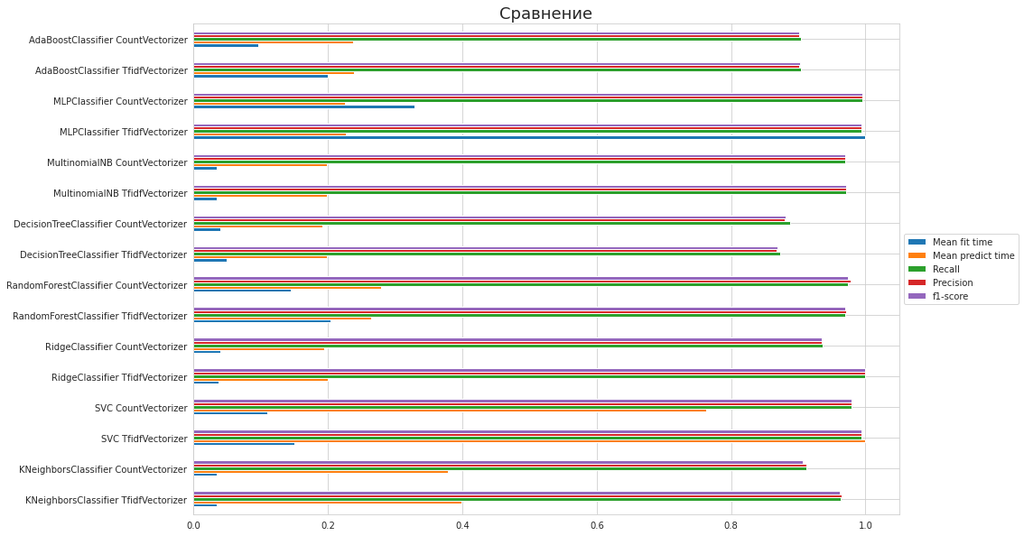

```python
compare = pd.DataFrame({'Mean fit time':
                          best_results['avg_fit_time']/best_results['avg_fit_time'].max(),
                       'Mean predict time':
                          best_results['avg_predict_time']/best_results['avg_predict_time'].max(),
                       'Recall':
                          best_results['recall_test']/best_results['recall_test'].max(),
                       'Precision':
                          best_results['precision_test']/best_results['precision_test'].max(),
                       'f1-score':
                          best_results['f1_test']/best_results['f1_test'].max()
                          },
                       index = best_results['name'])

fig = plt.figure(figsize=(14,10))
plt.title('Сравнение', fontdict={'fontsize':18})
compare.plot(kind='barh', ax=fig.gca())
plt.legend(loc='center left', bbox_to_anchor=(1.0, 0.5))
plt.show()
```

Лучшим (в балансе качества и времени) оказался TfidfVectorizer+RidgeClassifier. Эта таблица и предыдущая не сильно различаются.